# Les données Agribalyse (version 3.1)

Les données sont issues des données publiques du site de l'ADEME: https://agribalyse.ademe.fr/ Il est conseillé de parcourir la documentation de ces données sur le site ci-dessus pour se familiariser avec les différentes informations qu'elles fournissent.

Pour ce projet, vous travaillerez sur les données sur les produits alimentaires dont la version originale est visible ici : https://doc.agribalyse.fr/documentation/acces-donnees

Si vous n'arrivez pas à télécharger ou à ouvrir ce fichier, des versions de ce fichier au format libreoffice et au format Excel 97 sont fournies dans l'archive `data_tableur`. Il est conseillé de regarder un de ces fichiers car vous y trouverez des informations complémentaires sur les noms des colonnes des 3 fichiers CSV de `data` décrits ci-dessous.

Pour vous aider à manipuler les données nous vous fournissons dans l'archive `data` : les 3 tables du fichiers sont fournies sous la forme de 3 fichiers CSV directement lisibles par la commande `read_csv` de Pandas (le séparateur de colonnes est le `';'`). Ce sont ces 3 fichiers à utiliser dans votre notebook. Un exemple de chargement est donné plus loin dans ce notebook. Les fichiers sont:

- AGRIBALYSE3-ingredients.csv
- AGRIBALYSE3-etapes.csv
- AGRIBALYSE3-synthese.csv

**Remarque**: les données Agribalyse de 2021 ont fait l'objet du projet de l'an dernier, cette année c'est une nouvelle version étendue de ces données qui sont utilisées pour ce projet, nous attendons donc des analyses qui tirent partie des nouveautés de cette nouvelle version.

```python
# Importation des librairies standards:
import numpy as np
import pandas as pd
import matplotlib.pyplot as plt
%matplotlib inline

# Importation de votre librairie iads:
# La ligne suivante permet de préciser le chemin d'accès à la librairie iads
import sys
sys.path.append('../')   # iads doit être dans le répertoire frère du répertoire courant !

# Importation de la librairie iads
import iads as iads

# importation de Classifiers
from iads import Classifiers as cl

# importation de utils
from iads import utils as ut

# importation de evaluation
from iads import evaluation as ev

# importation de Clustering
from iads import Clustering as clust

# commande TRES utile pour recharger automatiquement le code que vous modifiez dans les modules
%load_ext autoreload
%autoreload 2
```

```
The autoreload extension is already loaded. To reload it, use:
  %reload_ext autoreload
```

```python
data_synthese = pd.read_csv("data/AGRIBALYSE3-synthese.csv", sep=';')
data_synthese.columns
print("Nombre de lignes: ",len(data_synthese))
print("Nombre de colonnes: ",len(data_synthese.columns))
```

```
Nombre de lignes:  2517
Nombre de colonnes:  29
```

```python
for i in range(0,len(data_synthese.columns)):
    if i>10:
        print("col ",i,": ",data_synthese.columns[i], "\tmoyenne = ",data_synthese[data_synthese.columns[i]].mean())
    else:
        print("col ",i,": ",data_synthese.columns[i])
```

```
col  0 :  Code AGB
col  1 :  Code CIQUAL
col  2 :  Groupe d'aliment
col  3 :  Sous-groupe d'aliment
col  4 :  Nom du Produit en Français
col  5 :  LCI Name
col  6 :  code saison
col  7 :  code avion
col  8 :  Livraison
col  9 :  Matériau d'emballage
col  10 :  Préparation
col  11 :  DQR 	moyenne =  2.7681644815256274
col  12 :  Score unique EF 3.1 	moyenne =  0.6889596344855025
col  13 :  Changement climatique 	moyenne =  5.420519666269371
col  14 :  Appauvrissement de la couche d'ozone 	moyenne =  5.383361620977347e-07
col  15 :  Rayonnements ionisants 	moyenne =  1.0168216924910598
col  16 :  Formation photochimique d'ozone 	moyenne =  0.0216259181565355
col  17 :  Particules fines 	moyenne =  5.735583075089373e-07
col  18 :  Effets toxicologiques sur la santé humaine : substances non-cancérogènes 	moyenne =  1.0743762415574125e-07
col  19 :  Effets toxicologiques sur la santé humaine : substances cancérogènes 	moyenne =  3.885454350417177e-09
col  20 :  Acidification terrestre et eaux douces 	moyenne =  0.07895298053237951
col  21 :  Eutrophisation eaux douces 	moyenne =  0.0008419094557012315
col  22 :  Eutrophisation marine 	moyenne =  0.02819352800953516
col  23 :  Eutrophisation terrestre 	moyenne =  0.31052913388955117
col  24 :  Écotoxicité pour écosystèmes aquatiques d'eau douce 	moyenne =  54.213323798172524
col  25 :  Utilisation du sol 	moyenne =  328.5981263408829
col  26 :  Épuisement des ressources eau 	moyenne =  5.726230393325388
col  27 :  Épuisement des ressources énergétiques 	moyenne =  49.799157727453334
col  28 :  Épuisement des ressources minéraux 	moyenne =  2.201983392928089e-05
```

```python
data_etapes = pd.read_csv("data/AGRIBALYSE3-etapes.csv", sep=';')
data_etapes.columns
print("Nombre de lignes: ",len(data_etapes))
print("Nombre de colonnes: ",len(data_etapes.columns))
```

```
Nombre de lignes:  2517
Nombre de colonnes:  132
```

```python
for i in range(0,len(data_etapes.columns)):
    print("col ",i,": ",data_etapes.columns[i])
```

```
col  0 :  Code AGB
col  1 :  Code CIQUAL
col  2 :  Groupe d aliment
col  3 :  Sous-groupe d aliment
col  4 :  Nom du Produit en Français
col  5 :  LCI Name
col  6 :  DQR
col  7 :  Nom et code
col  8 :  Agriculture
col  9 :  Transformation
col  10 :  Emballage
col  11 :  Transport
col  12 :  Supermarché et distribution
col  13 :  Consommation
col  14 :  Total
col  15 :  Agriculture.1
col  16 :  Transformation.1
col  17 :  Emballage.1
col  18 :  Transport.1
col  19 :  Supermarché et distribution.1
col  20 :  Consommation.1
col  21 :  Total.1
col  22 :  Agriculture.2
col  23 :  Transformation.2
col  24 :  Emballage.2
col  25 :  Transport.2
col  26 :  Supermarché et distribution.2
col  27 :  Consommation.2
col  28 :  Total.2
col  29 :  Agriculture.3
col  30 :  Transformation.3
col  31 :  Emballage.3
col  32 :  Transport.3
col  33 :  Supermarché et distribution.3
col  34 :  Consommation.3
col  35 :  Total.3
col  36 :  Agriculture.4
col  37 :  Transformation.4
col  38 :  Emballage.4
col  39 :  Transport.4
```

[output cut: 77 more lines]

```
col  117 :  Supermarché et distribution.15
col  118 :  Consommation.15
col  119 :  Total.15
col  120 :  Agriculture.16
col  121 :  Transformation.16
col  122 :  Emballage.16
col  123 :  Transport.16
col  124 :  Supermarché et distribution.16
col  125 :  Consommation.16
col  126 :  Total.16
col  127 :  DQR Overall
col  128 :  P
col  129 :  TiR
col  130 :  GR
col  131 :  TeR
```

```python
print("Quelques infos :")
for i in range(0,17):
    print("----")
    for col in ['Agriculture', 'Transformation', 'Emballage', 'Transport', 'Supermarché et distribution', \
                'Consommation', 'Total']:
        if i>0:
            nom_col = col + "." +str(i)
        else:
            nom_col = col
        print(nom_col,"\tmoyenne = ",data_etapes[nom_col].mean())
```

```
Quelques infos :
----
Agriculture 	moyenne =  0.5684966870458406
Transformation 	moyenne =  0.056136918226633324
Emballage 	moyenne =  0.02242675546471597
Transport 	moyenne =  0.026165883152808857
Supermarché et distribution 	moyenne =  0.007877125406877268
Consommation 	moyenne =  0.007633790367775273
Total 	moyenne =  0.6887371596646522
----
Agriculture.1 	moyenne =  4.283405101720905
Transformation.1 	moyenne =  0.4956679004686108
Emballage.1 	moyenne =  0.25511460216686355
Transport.1 	moyenne =  0.31395988182510964
Supermarché et distribution.1 	moyenne =  0.03147132845606259
Consommation.1 	moyenne =  0.042848097985972104
Total.1 	moyenne =  5.422466912623518
----
Agriculture.2 	moyenne =  3.3849700977868863e-07
Transformation.2 	moyenne =  3.3468371653456784e-08
Emballage.2 	moyenne =  8.733627654263909e-08
Transport.2 	moyenne =  7.39595480802746e-08
Supermarché et distribution.2 	moyenne =  2.4693114096368837e-09
Consommation.2 	moyenne =  2.6369538328196176e-09
Total.2 	moyenne =  5.383674712975938e-07
----
Agriculture.3 	moyenne =  0.22347594415358327
Transformation.3 	moyenne =  0.509689582884064
Emballage.3 	moyenne =  0.026443116230250266
Transport.3 	moyenne =  0.020708397043810254
Supermarché et distribution.3 	moyenne =  0.124289809269087
Consommation.3 	moyenne =  0.11212322565223509
Total.3 	moyenne =  1.0167300752330282
----
Agriculture.4 	moyenne =  0.018124962240729955
Transformation.4 	moyenne =  0.0011453623181971702
Emballage.4 	moyenne =  0.0007314176762902194
Transport.4 	moyenne =  0.0014836005704080204
Supermarché et distribution.4 	moyenne =  6.676431156404086e-05
Consommation.4 	moyenne =  7.66614940653192e-05
```

[output cut: 82 more lines]

```
Agriculture.15 	moyenne =  21.537600423417633
Transformation.15 	moyenne =  14.029094337067578
Emballage.15 	moyenne =  4.567783046302378
Transport.15 	moyenne =  4.288577241244697
Supermarché et distribution.15 	moyenne =  2.770083682731052
Consommation.15 	moyenne =  2.549797561227566
Total.15 	moyenne =  49.74293629199102
----
Agriculture.16 	moyenne =  0.015244014435140198
Transformation.16 	moyenne =  0.0023014939844706655
Emballage.16 	moyenne =  0.001662843844455704
Transport.16 	moyenne =  0.0012823188364461699
Supermarché et distribution.16 	moyenne =  0.0007804375020440739
Consommation.16 	moyenne =  0.0007088726532150333
Total.16 	moyenne =  0.021979981255771795
```

```python
data_ingredients = pd.read_csv("data/AGRIBALYSE3-ingredients.csv",sep=";")
data_ingredients.columns
print("Nombre de lignes: ",len(data_ingredients))
print("Nombre de colonnes: ",len(data_ingredients.columns))
```

```
Nombre de lignes:  6856
Nombre de colonnes:  27
```

```python
for i in range(0,len(data_ingredients.columns)):
    if i<10:
        print(i,": ", data_ingredients.columns[i])
    else:
        print(i,": ", data_ingredients.columns[i], \
              "\tmoyennne = ", data_ingredients[data_ingredients.columns[i]].mean())
```

```
0 :  Ciqual AGB
1 :  Ciqual code
2 :  Groupe d'aliment
3 :  Sous-groupe d'aliment
4 :  Nom Français
5 :  LCI Name
6 :  Ingredients
7 :  Code et Nom
8 :  Groupe
9 :  Sous-groupe
10 :  Formation photochimique d'ozone 	moyennne =  0.14901077587806696
11 :  Particules fines 	moyennne =  1.1694919040652145
12 :  Effets toxicologiques sur la santé humaine : substances non-cancérogènes 	moyennne =  9.663670448533415e-08
13 :  Effets toxicologiques sur la santé humaine : substances cancérogènes 	moyennne =  0.32177220746506924
14 :  Acidification terrestre et eaux douces 	moyennne =  0.0038680513541169905
15 :  Eutrophisation eaux douces 	moyennne =  1.1525166083035612e-07
16 :  Eutrophisation marine 	moyennne =  2.5530761424091244e-08
17 :  Eutrophisation terrestre 	moyennne =  9.025745752722709e-10
18 :  Écotoxicité pour écosystèmes aquatiques d'eau douce 	moyennne =  0.015834018204143707
19 :  Utilisation du sol 	moyennne =  0.0001705105635242942
20 :  Épuisement des ressources eau 	moyennne =  0.005420029504769188
21 :  Épuisement des ressources énergétiques 	moyennne =  0.06377478486649865
22 :  Épuisement des ressources minéraux 	moyennne =  13.45604458169234
23 :  Pt/kg de produit 	moyennne =  70.52662867740453
24 :  m3 depriv./kg de produit 	moyennne =  1.362213190190878
25 :  MJ/kg de produit 	moyennne =  12.915748203498485
26 :  kg Sb eq/kg de produit 	moyennne =  4.652159787008768e-06
```

```python
data_synthese
```

|  | Code AGB | Code CIQUAL | Groupe d'aliment | Sous-groupe d'aliment | Nom du Produit en Français | LCI Name | code saison | code avion | Livraison | Matériau d'emballage | ... | Effets toxicologiques sur la santé humaine : substances cancérogènes | Acidification terrestre et eaux douces | Eutrophisation eaux douces | Eutrophisation marine | Eutrophisation terrestre | Écotoxicité pour écosystèmes aquatiques d'eau douce | Utilisation du sol | Épuisement des ressources eau | Épuisement des ressources énergétiques | Épuisement des ressources minéraux |
| --- | --- | --- | --- | --- | --- | --- | --- | --- | --- | --- | --- | --- | --- | --- | --- | --- | --- | --- | --- | --- | --- |
| 0 | 11084 | 11084 | aides culinaires et ingrédients divers | algues | Agar (algue), cru | Seaweed, agar, raw | 2 | 0 | Ambiant (long) | LDPE | ... | 6.480000e-09 | 0.09970 | 0.001870 | 0.01330 | 0.12700 | 44.60 | 26.5 | 3.100 | 315.00 | 0.000088 |
| 1 | 11023 | 11023 | aides culinaires et ingrédients divers | herbes | Ail séché, poudre | Garlic, powder, dried | 2 | 0 | Ambiant (long) | Verre | ... | 4.660000e-10 | 0.00622 | 0.000124 | 0.00232 | 0.01270 | 5.83 | 20.2 | 2.520 | 12.70 | 0.000007 |
| 2 | 11000 | 11000 | aides culinaires et ingrédients divers | herbes | Ail, cru | Garlic, fresh | 2 | 0 | Ambiant (long) | Pas d'emballage | ... | 2.980000e-10 | 0.00200 | 0.000068 | 0.00212 | 0.00628 | 4.09 | 18.5 | 3.020 | 6.23 | 0.000004 |
| 3 | 11093 | 11093 | aides culinaires et ingrédients divers | herbes | Aneth, frais | Dill, fresh | 2 | 0 | Ambiant (long) | LDPE | ... | 6.190000e-10 | 0.00811 | 0.000203 | 0.00405 | 0.03120 | 5.68 | 36.4 | 5.290 | 12.60 | 0.000005 |
| 4 | 20995 | 20995 | aides culinaires et ingrédients divers | algues | Ao-nori (Enteromorpha sp.), séchée ou déshydratée | Sea lettuce (Enteromorpha sp.), dried or dehyd... | 2 | 0 | Ambiant (long) | LDPE | ... | 6.480000e-09 | 0.09970 | 0.001870 | 0.01330 | 0.12700 | 44.60 | 26.5 | 3.100 | 315.00 | 0.000088 |
| ... | ... | ... | ... | ... | ... | ... | ... | ... | ... | ... | ... | ... | ... | ... | ... | ... | ... | ... | ... | ... | ... |
| 2512 | 6535 | 6535 | viandes, œufs, poissons | viandes crues | Veau, steak haché 20% MG, cru | Veal, minced steak, 20% fat, raw | 2 | 0 | Glacé | PS | ... | 1.080000e-08 | 0.22500 | 0.002210 | 0.15600 | 0.96000 | 193.00 | 1520.0 | 6.280 | 111.00 | 0.000038 |
| 2513 | 6582 | 6582 | viandes, œufs, poissons | viandes cuites | Veau, tête, bouillie/cuite à l'eau | Calf, head, boiled/cooked in water | 2 | 0 | Glacé | PS | ... | 1.120000e-08 | 0.23200 | 0.002300 | 0.16000 | 0.99000 | 200.00 | 1570.0 | 6.520 | 116.00 | 0.000041 |
| 2514 | 26146 | 26146 | viandes, œufs, poissons | poissons crus | Vivaneau, cru | Snapper, raw | 2 | 0 | Glacé | PS | ... | 4.020000e-09 | 0.09540 | 0.000677 | 0.02250 | 0.24400 | 24.10 | 14.7 | 0.559 | 60.60 | 0.000163 |
| 2515 | 26147 | 26147 | viandes, œufs, poissons | poissons cuits | Vivaneau, cuit | Snapper, cooked | 2 | 0 | Glacé | PP | ... | 5.000000e-09 | 0.11700 | 0.000867 | 0.02750 | 0.29900 | 29.30 | 18.7 | 0.643 | 86.30 | 0.000203 |
| 2516 | 25512 | 25512 | viandes, œufs, poissons | autres produits à base de viande | Volaille, croquette panée ou nuggets | Poultry nuggets | 2 | 0 | Glacé | PS | ... | 4.910000e-09 | 0.10300 | 0.000987 | 0.02660 | 0.43700 | 86.10 | 342.0 | 4.030 | 96.40 | 0.000025 |

2517 rows × 29 columns

```python
data_etapes
```

|  | Code AGB | Code CIQUAL | Groupe d aliment | Sous-groupe d aliment | Nom du Produit en Français | LCI Name | DQR | Nom et code | Agriculture | Transformation | ... | Emballage.16 | Transport.16 | Supermarché et distribution.16 | Consommation.16 | Total.16 | DQR Overall | P | TiR | GR | TeR |
| --- | --- | --- | --- | --- | --- | --- | --- | --- | --- | --- | --- | --- | --- | --- | --- | --- | --- | --- | --- | --- | --- |
| 0 | 11084 | 11084 | aides culinaires et ingrédients divers | algues | Agar (algue). cru | Seaweed. agar. raw | 2.99 | Agar (algue). cru (11084) | 0.654812 | 0.500987 | ... | 0.001043 | 0.000899 | 0.000460 | 0.000002 | 0.087558 | 2.99 | 3.51 | 1.32 | 4.33 | 2.79 |
| 1 | 11023 | 11023 | aides culinaires et ingrédients divers | herbes | Ail séché. poudre | Garlic. powder. dried | 4.11 | Ail séché. poudre (11023) | 0.032661 | 0.000000 | ... | 0.003464 | 0.000671 | 0.000440 | 0.000000 | 0.006605 | 4.11 | 4.27 | 4.39 | 2.79 | 5.00 |
| 2 | 11000 | 11000 | aides culinaires et ingrédients divers | herbes | Ail. cru | Garlic. fresh | 3.54 | Ail. cru (11000) | 0.040826 | 0.000000 | ... | 0.000000 | 0.000614 | 0.000550 | 0.000016 | 0.003717 | 3.54 | 2.74 | 4.28 | 2.80 | 4.34 |
| 3 | 11093 | 11093 | aides culinaires et ingrédients divers | herbes | Aneth. frais | Dill. fresh | 3.75 | Aneth. frais (11093) | 0.082933 | 0.000000 | ... | 0.001150 | 0.000583 | 0.000550 | 0.000016 | 0.004779 | 3.75 | 2.74 | 3.62 | 4.33 | 4.33 |
| 4 | 20995 | 20995 | aides culinaires et ingrédients divers | algues | Ao-nori (Enteromorpha sp.). séchée ou déshydratée | Sea lettuce (Enteromorpha sp.). dried or dehyd... | 2.99 | Ao-nori (Enteromorpha sp.). séchée ou déshydra... | 0.654812 | 0.500987 | ... | 0.001043 | 0.000899 | 0.000460 | 0.000002 | 0.087558 | 2.99 | 3.51 | 1.32 | 4.33 | 2.79 |
| ... | ... | ... | ... | ... | ... | ... | ... | ... | ... | ... | ... | ... | ... | ... | ... | ... | ... | ... | ... | ... | ... |
| 2512 | 6535 | 6535 | viandes. œufs. poissons | viandes crues | Veau. steak haché 20% MG. cru | Veal. minced steak. 20% fat. raw | 2.47 | Veau. steak haché 20% MG. cru (6535) | 2.085451 | 0.045533 | ... | 0.000034 | 0.000926 | 0.000914 | 0.000263 | 0.038303 | 2.47 | 3.77 | 2.02 | 2.01 | 2.08 |
| 2513 | 6582 | 6582 | viandes. œufs. poissons | viandes cuites | Veau. tête. bouillie/cuite à l eau | Calf. head. boiled/cooked in water | 2.45 | Veau. tête. bouillie/cuite à l eau (6582) | 2.147376 | 0.010702 | ... | 0.000053 | 0.001432 | 0.001443 | 0.002279 | 0.041251 | 2.45 | 3.66 | 1.28 | 2.04 | 2.82 |
| 2514 | 26146 | 26146 | viandes. œufs. poissons | poissons crus | Vivaneau. cru | Snapper. raw | 3.68 | Vivaneau. cru (26146) | 0.719615 | 0.000000 | ... | 0.000034 | 0.003652 | 0.000914 | 0.000263 | 0.163057 | 3.68 | 4.60 | 2.54 | 2.59 | 5.00 |
| 2515 | 26147 | 26147 | viandes. œufs. poissons | poissons cuits | Vivaneau. cuit | Snapper. cooked | 3.56 | Vivaneau. cuit (26147) | 0.878692 | 0.000000 | ... | 0.000939 | 0.004459 | 0.001116 | 0.003711 | 0.203390 | 3.56 | 4.30 | 2.62 | 2.34 | 5.00 |
| 2516 | 25512 | 25512 | viandes. œufs. poissons | autres produits à base de viande | Volaille. croquette panée ou nuggets | Poultry nuggets | 2.79 | Volaille. croquette panée ou nuggets (25512) | 0.633044 | 0.129015 | ... | 0.001633 | 0.000944 | 0.000915 | 0.003653 | 0.025358 | 2.79 | 3.77 | 2.32 | 1.63 | 3.42 |

2517 rows × 132 columns

```python
data_ingredients
```

|  | Ciqual AGB | Ciqual code | Groupe d'aliment | Sous-groupe d'aliment | Nom Français | LCI Name | Ingredients | Code et Nom | Groupe | Sous-groupe | ... | Eutrophisation terrestre | Écotoxicité pour écosystèmes aquatiques d'eau douce | Utilisation du sol | Épuisement des ressources eau | Épuisement des ressources énergétiques | Épuisement des ressources minéraux | Pt/kg de produit | m3 depriv./kg de produit | MJ/kg de produit | kg Sb eq/kg de produit |
| --- | --- | --- | --- | --- | --- | --- | --- | --- | --- | --- | --- | --- | --- | --- | --- | --- | --- | --- | --- | --- | --- |
| 0 | 37000 | 37000 | aides culinaires et ingrédients divers | ingrédients divers | Base de pizza à la crème | cream sauce for pizza base | Fromage frais crémeux | Base de pizza à la crème (37000) | aides culinaires et ingrédients divers | ingrédients divers | ... | 1.240000e-09 | 0.017200 | 0.000222 | 0.005420 | 0.072300 | 17.500000 | 90.100000 | 0.310000 | 8.090000 | 1.480000e-05 |
| 1 | 37000 | 37000 | aides culinaires et ingrédients divers | ingrédients divers | Base de pizza à la crème | cream sauce for pizza base | Autres étapes | Base de pizza à la crème (37000) | aides culinaires et ingrédients divers | ingrédients divers | ... | 2.340000e-10 | 0.002160 | 0.000090 | 0.001300 | 0.006980 | 2.310000 | 9.060000 | 0.144000 | 15.300000 | 2.320000e-06 |
| 2 | 37000 | 37000 | aides culinaires et ingrédients divers | ingrédients divers | Base de pizza à la crème | cream sauce for pizza base | Total | Base de pizza à la crème (37000) | aides culinaires et ingrédients divers | ingrédients divers | ... | 1.470000e-09 | 0.019300 | 0.000312 | 0.006730 | 0.079300 | 19.900000 | 99.200000 | 0.455000 | 23.400000 | 1.710000e-05 |
| 3 | 37002 | 37002 | aides culinaires et ingrédients divers | ingrédients divers | Base de pizza tomatée | Tomato sauce for pizza base | Huile d'olive | Base de pizza tomatée (37002) | aides culinaires et ingrédients divers | ingrédients divers | ... | 4.180000e-10 | 0.003770 | 0.000052 | 0.001740 | 0.015800 | 5.580000 | 54.300000 | 1.950000 | 1.720000 | 1.890000e-06 |
| 4 | 37002 | 37002 | aides culinaires et ingrédients divers | ingrédients divers | Base de pizza tomatée | Tomato sauce for pizza base | Oignons | Base de pizza tomatée (37002) | aides culinaires et ingrédients divers | ingrédients divers | ... | 1.370000e-11 | 0.000111 | 0.000003 | 0.000125 | 0.000408 | 0.231000 | 0.998000 | 0.165000 | 0.138000 | 1.520000e-07 |
| ... | ... | ... | ... | ... | ... | ... | ... | ... | ... | ... | ... | ... | ... | ... | ... | ... | ... | ... | ... | ... | ... |
| 6851 | 25512 | 25512 | viandes, œufs, poissons | autres produits à base de viande | Volaille, croquette panée ou nuggets | Poultry nuggets | Viande | Volaille, croquette panée ou nuggets (25512) | viandes, œufs, poissons | autres produits à base de viande | ... | 3.876827e-09 | 0.089629 | 0.000791 | 0.021372 | 0.385901 | 72.852216 | 283.404190 | 3.379838 | 60.658757 | 1.696759e-05 |
| 6852 | 25512 | 25512 | viandes, œufs, poissons | autres produits à base de viande | Volaille, croquette panée ou nuggets | Poultry nuggets | Lait demi-écremé | Volaille, croquette panée ou nuggets (25512) | viandes, œufs, poissons | autres produits à base de viande | ... | 1.559162e-10 | 0.002703 | 0.000026 | 0.000870 | 0.011714 | 2.737303 | 14.705075 | 0.076615 | 0.695539 | 5.546857e-07 |
| 6853 | 25512 | 25512 | viandes, œufs, poissons | autres produits à base de viande | Volaille, croquette panée ou nuggets | Poultry nuggets | Farine de blé | Volaille, croquette panée ou nuggets (25512) | viandes, œufs, poissons | autres produits à base de viande | ... | 3.501547e-10 | 0.003277 | 0.000048 | 0.002206 | 0.014150 | 4.221226 | 28.688275 | 0.095506 | 1.495995 | 9.948229e-07 |
| 6854 | 25512 | 25512 | viandes, œufs, poissons | autres produits à base de viande | Volaille, croquette panée ou nuggets | Poultry nuggets | Autres étapes | Volaille, croquette panée ou nuggets (25512) | viandes, œufs, poissons | autres produits à base de viande | ... | 3.606422e-10 | 0.003243 | 0.000087 | 0.001362 | 0.008688 | 2.725231 | 4.999133 | 0.285816 | 32.821669 | 6.377483e-06 |
| 6855 | 25512 | 25512 | viandes, œufs, poissons | autres produits à base de viande | Volaille, croquette panée ou nuggets | Poultry nuggets | Total | Volaille, croquette panée ou nuggets (25512) | viandes, œufs, poissons | autres produits à base de viande | ... | 4.905220e-09 | 0.102578 | 0.000987 | 0.026625 | 0.436752 | 86.087428 | 342.123719 | 4.029214 | 96.404511 | 2.535503e-05 |

6856 rows × 27 columns

# Debut du projet

**Existe-t-il un regroupement d’aliments divers ayant un impact environnementale faible ? Cela prend en compte diffèrents aliments permettant de former un regroupement aliments riche en diversité de nutriments pour un humain(ex: protéine,glucide,..).Ce regroupement d'aliment a-t-il un taux substance cancérigènes élévée ?**

```python
"""filtrage des data_synthese et data_etapes en gardant que les DQR < 3.(" La Commission Européenne recommande de la
prudence dans l’utilisation des données avec des DQR supérieurs à 3") """

data_synthese2 = data_synthese[data_synthese["DQR"]<3]
data_etapes2 = data_etapes[data_etapes["DQR"]<3]
```

# Analyse

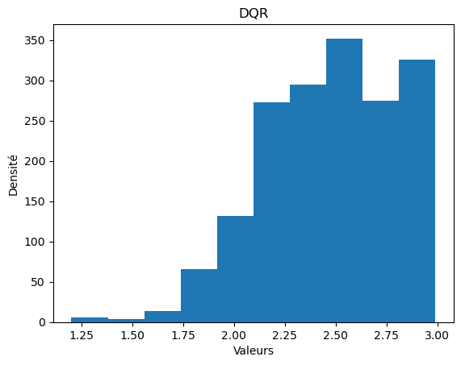

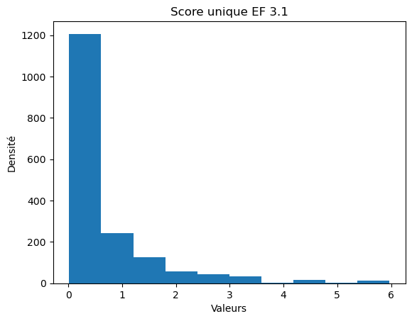

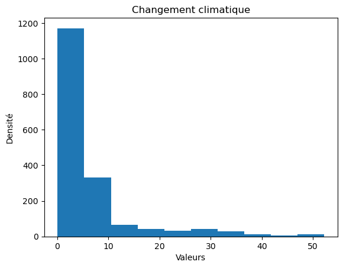

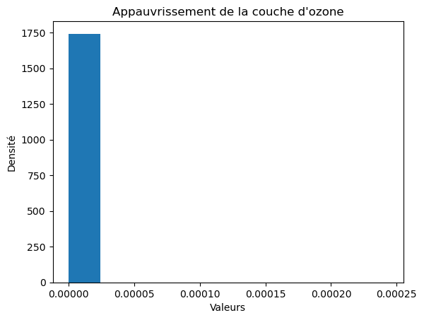

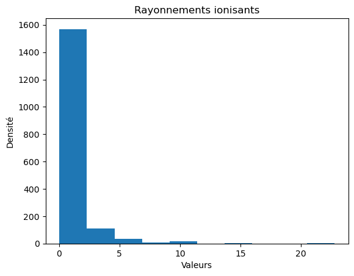

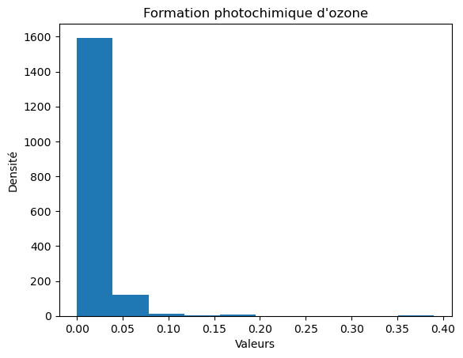

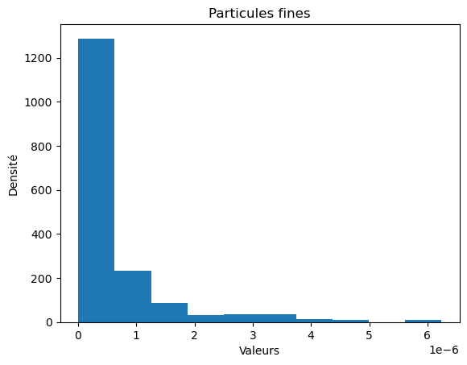

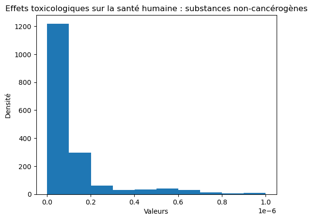

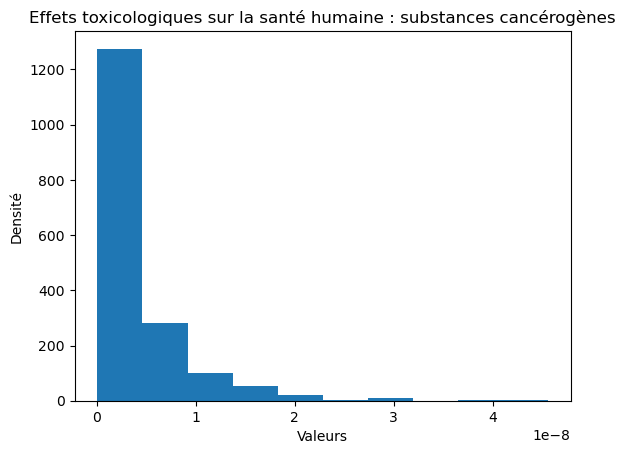

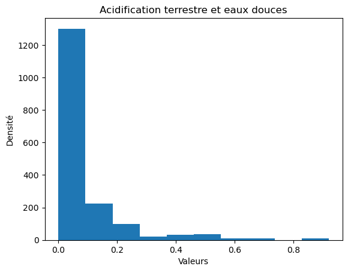

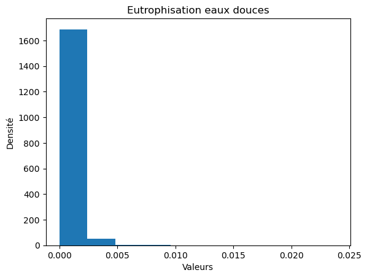

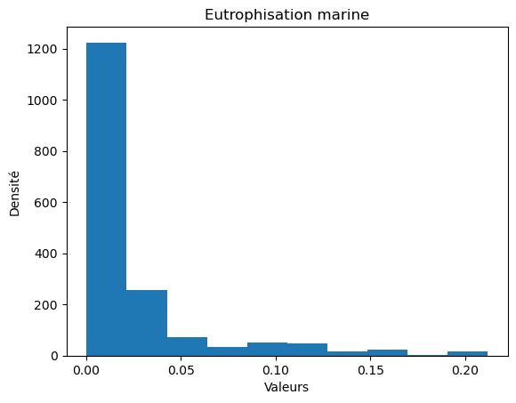

[6 more figures not shown]

```python
#Affichage approximative de la distribution des données de chaque colonnes quantitatives

for col in data_synthese2.select_dtypes('float'):
    plt.figure()
    plt.hist(data_synthese2[col])
    plt.xlabel('Valeurs')
    plt.ylabel('Densité')
    plt.title(data_synthese2[col].name)
    plt.show()
```

```python
#Affichage des variables qualitatives (utile pour plus tard)
for col in data_synthese2.select_dtypes('object'):
    print(f'{col :-<50} {data_synthese2[col].unique()}')
```

```
Code AGB------------------------------------------ ['11084' '20995' '20998' ... '6535' '6582' '25512']
Groupe d'aliment---------------------------------- ['aides culinaires et ingrédients divers' 'aliments infantiles' 'boissons'
 'entrées et plats composés' 'fruits, légumes, légumineuses et oléagineux'
 'glaces et sorbets' 'lait et produits laitiers' 'matières grasses'
 'produits céréaliers' 'produits sucrés' 'viandes, œufs, poissons']
Sous-groupe d'aliment----------------------------- ['algues' 'ingrédients divers' 'sauces' 'sels' 'condiments' 'herbes'
 'épices' 'aides culinaires' 'céréales et biscuits infantiles'
 'desserts infantiles' 'laits et boissons infantiles'
 'petits pots salés et plats infantiles' 'boisson alcoolisées'
 'boissons sans alcool' 'eaux' 'plats composés'
 'feuilletées et autres entrées' 'soupes' 'plats végétariens' 'sandwichs'
 'pizzas, tartes et crêpes salées' 'salades composées et crudités'
 'fruits' 'légumes' 'pommes de terre et autres tubercules'
 'fruits à coque et graines oléagineuses' 'sorbets' 'desserts glacés'
 'fromages' 'produits laitiers frais et assimilés' 'laits' 'beurres'
 'huiles et graisses végétales' 'autres matières grasses' 'margarines'
 'gâteaux et pâtisseries' 'pains et viennoiseries'
 'céréales de petit-déjeuner et biscuits' 'pâtes, riz et céréales'
 'farines et pâtes à tarte' 'chocolats et produits à base de chocolat'
 'confiseries non chocolatées' 'confitures et assimilés'
 'sucres, miels et assimilés' 'viandes cuites' 'viandes crues'
 'charcuteries' 'autres produits à base de viande' 'substituts de viande'
 'mollusques et crustacés crus' 'mollusques et crustacés cuits'
 'produits à base de poissons et produits de la mer' 'œufs'
 'substituts de charcuterie' 'poissons cuits']
Nom du Produit en Français------------------------ ['Agar (algue), cru' 'Ao-nori (Enteromorpha sp.), séchée ou déshydratée'
 'Ascophylle noueux ou goémon noir (Ascophyllum nodosum), séché ou déshydraté'
 ... 'Veau, steak haché 20% MG, cru' "Veau, tête, bouillie/cuite à l'eau"
 'Volaille, croquette panée ou nuggets']
LCI Name------------------------------------------ ['Seaweed, agar, raw'
 'Sea lettuce (Enteromorpha sp.), dried or dehydrated'
 'North Atlantic rockweed (Ascophyllum nodosum), dried or dehydrated' ...
 'Veal, minced steak, 20% fat, raw' 'Calf, head, boiled/cooked in water'
 'Poultry nuggets']
Livraison----------------------------------------- ['Ambiant (long)' 'Glacé' 'Congelé' 'Ambiant (moyen)' 'Ambiant (court)']
Matériau d'emballage------------------------------ ['LDPE' 'Carton' 'PVC' 'Papier' 'Verre' 'PET' 'PP' 'HPDE' 'HDPE' 'PS'
 'Carton et Aluminium' 'Acier' "Pas d'emballage" 'PP/PE' 'Aluminium'
 'Carton et LDPE' 'PPE/PE']
Préparation--------------------------------------- ['Pas de préparation' 'Micro-onde ' 'Réfrigéré chez le consommateur'
 "Cuisson à l'eau" 'Four ' 'Four' 'Poêle' 'Friture' 'Micro-onde']
```

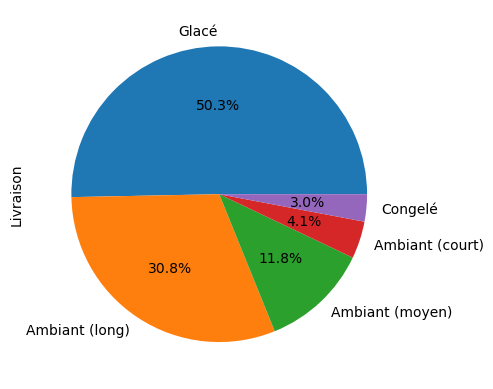

```python
#Histogramme des pourcentages des diffèrentes types de livraison effectué

plt.figure()
data_synthese2["Livraison"].value_counts().plot.pie(autopct='%1.1f%%')
```

On peut constater que les livraisons sont principalement effectué dans des conditions glacé qui représente 50.3% des livraisons au total. Les autres livraisons sont sous des conditions ambiant long et moyen. Ces livraisons sont pour une meilleure conservation des aliments durant le transport.

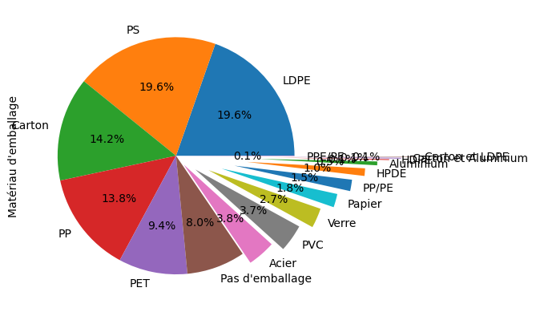

```python
#Histogramme des pourcentages des diffèrentes types de matériaux d'emballage

explode = (0,0,0,0,0,0,0.1,0.2,0.3,0.4,0.5,0.6,0.7,0.8,0.9,1,0)

plt.figure()
data_synthese2["Matériau d'emballage"].value_counts().plot.pie(explode=explode,autopct='%1.1f%%')
```

Les matériaux d'emballage le plus abondamment utilisé sont le plastique tel que le PS,LDPE,PP et PET mais aussi le Carton. Le problème se pose sur le recyclage total de ces emballages et leur impacte sur l'environnement.

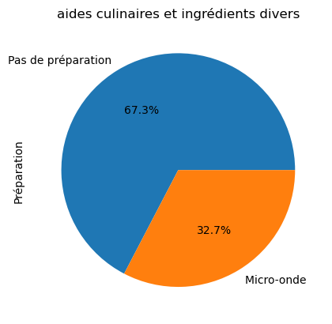

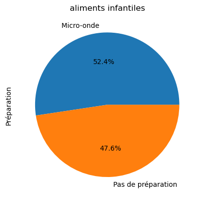

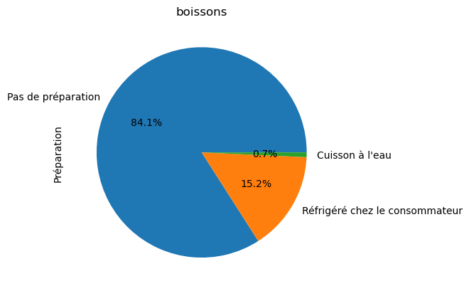

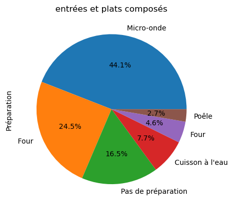

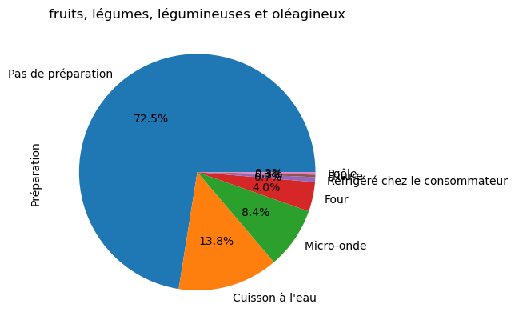

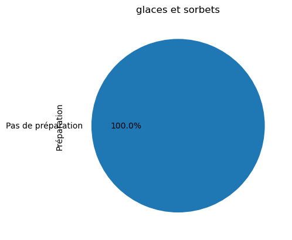

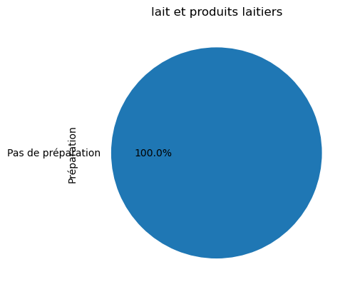

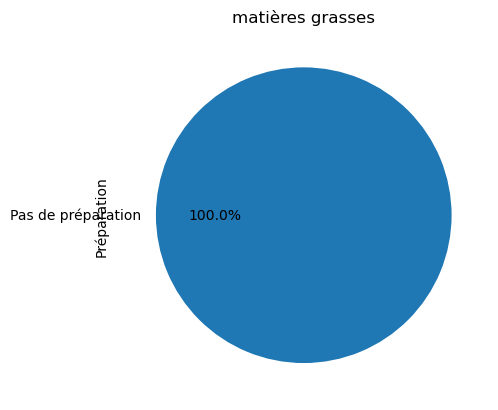

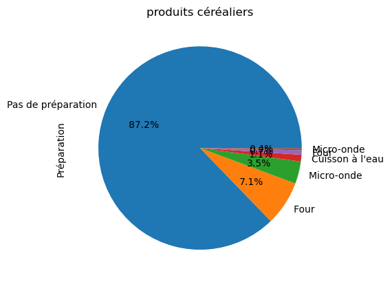

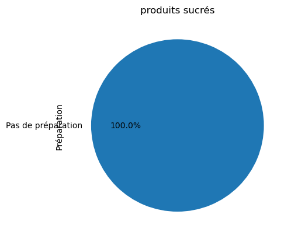

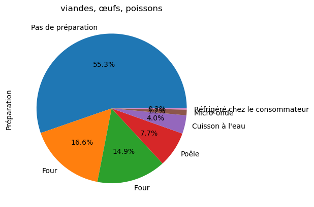

```python
#Histogramme des pourcentages des diffèrentes préparation effectués selon le groupe aliment

for gr_aliment in data_synthese2["Groupe d'aliment"].unique():
    plt.figure()
    plt.title(gr_aliment)
    data_synthese2[data_synthese2["Groupe d'aliment"]==gr_aliment]["Préparation"].value_counts().plot.pie(autopct='%1.1f%%')
```